# Cook’s Distance for Observation Selection- MC experiments

Weihao Li

2020-10-10

# Correct DGP

Assume We have such a data generating process:

$$Y_t = \beta_0 + \varepsilon_t, \varepsilon_t \sim N(0,10^2), t = 1,2,..,T$$

And then use the `lm` function to fit a model with only a constant term.

$$\hat{y}_t = \hat{\beta}_0$$

The MLE or the OLS solution for this model is $\hat{\beta}_0 = \frac{1}{T}\sum_{t=1}^{T}y_t$

After that, we use the Cook’s distance to drop observation with value greater than $\frac{4}{T}$. Refit the model, and record the coefficient as $\hat{\beta}_{0,Cook}$.

The aim of this experiment is to understand the behavior of $\hat{\beta}_0$ and $\hat{\beta}_{0,Cook}$.

Theoretically, with correctly specified model, MLE is asymptotically efficient, which reach the Cramer Rao lower bound.

**Thus, if we believe our model is correct, don’t use Cook’s Distance to drop any observation.**

As you can see from the sampling distribution, MLE always has a smaller variance, no matter what the sample size is.

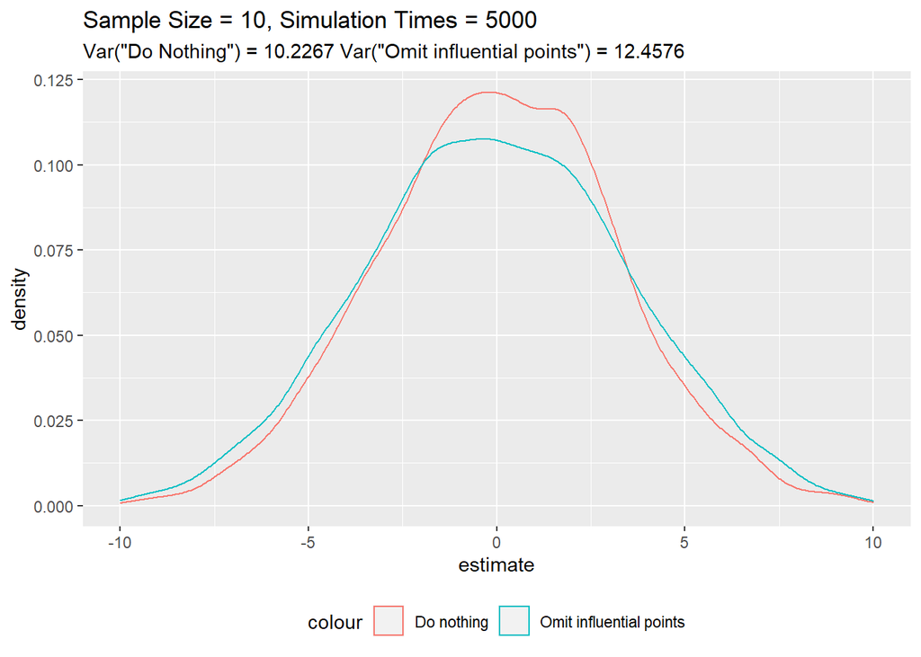

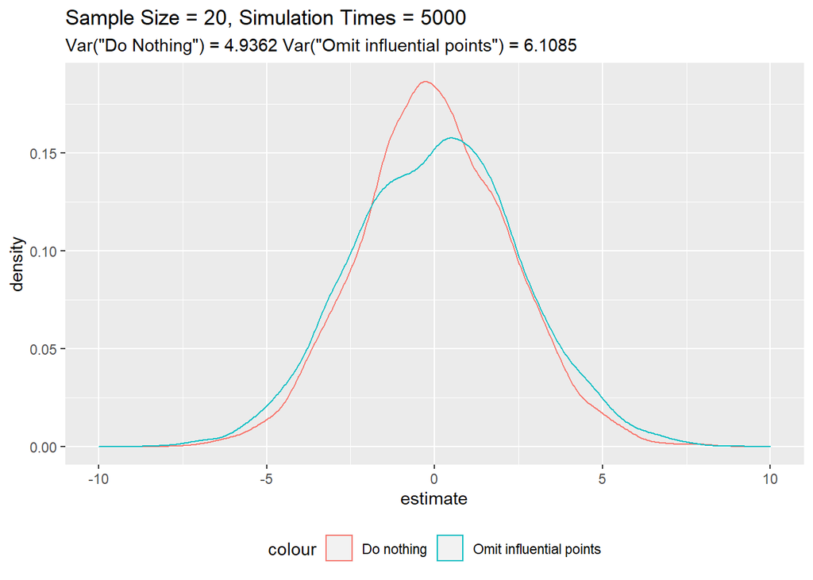

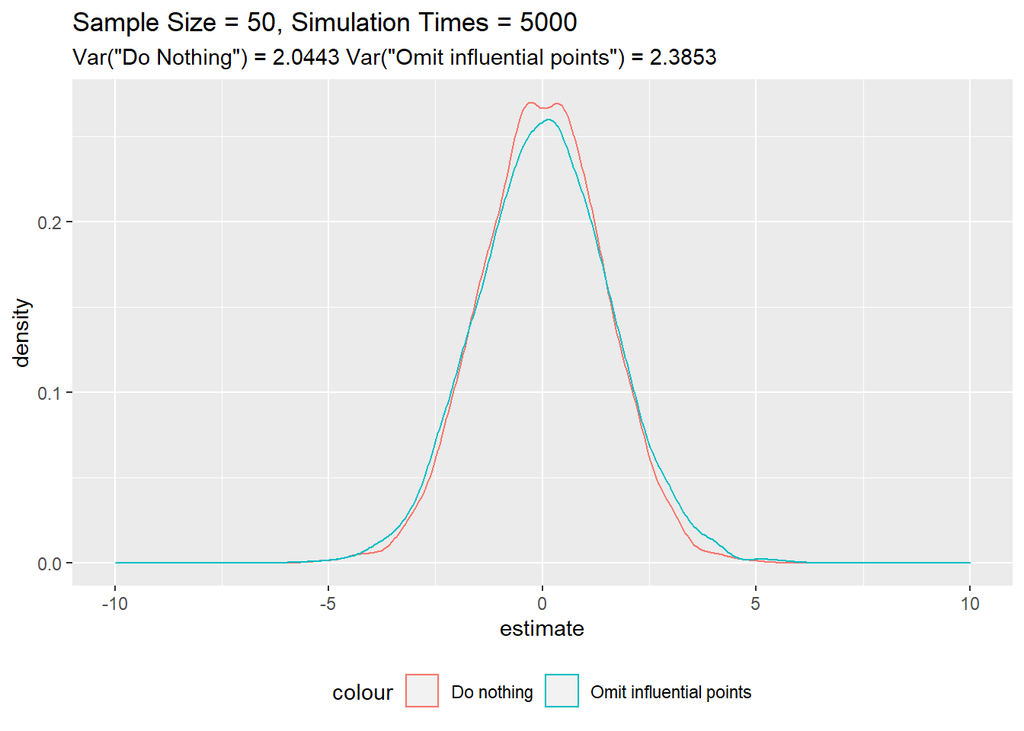

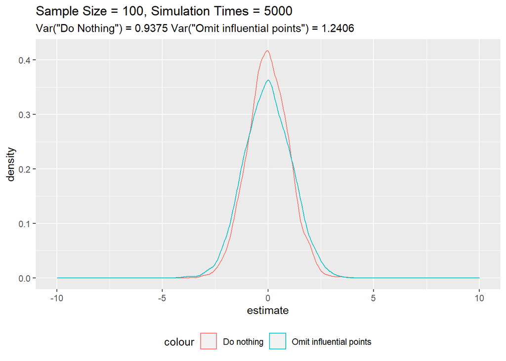

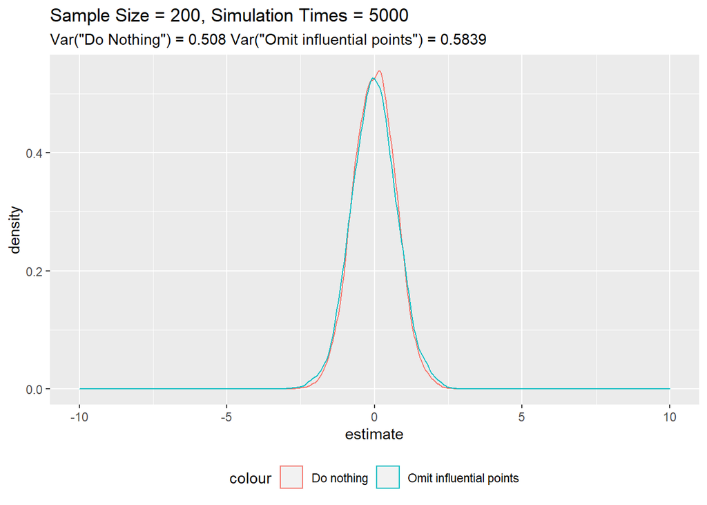

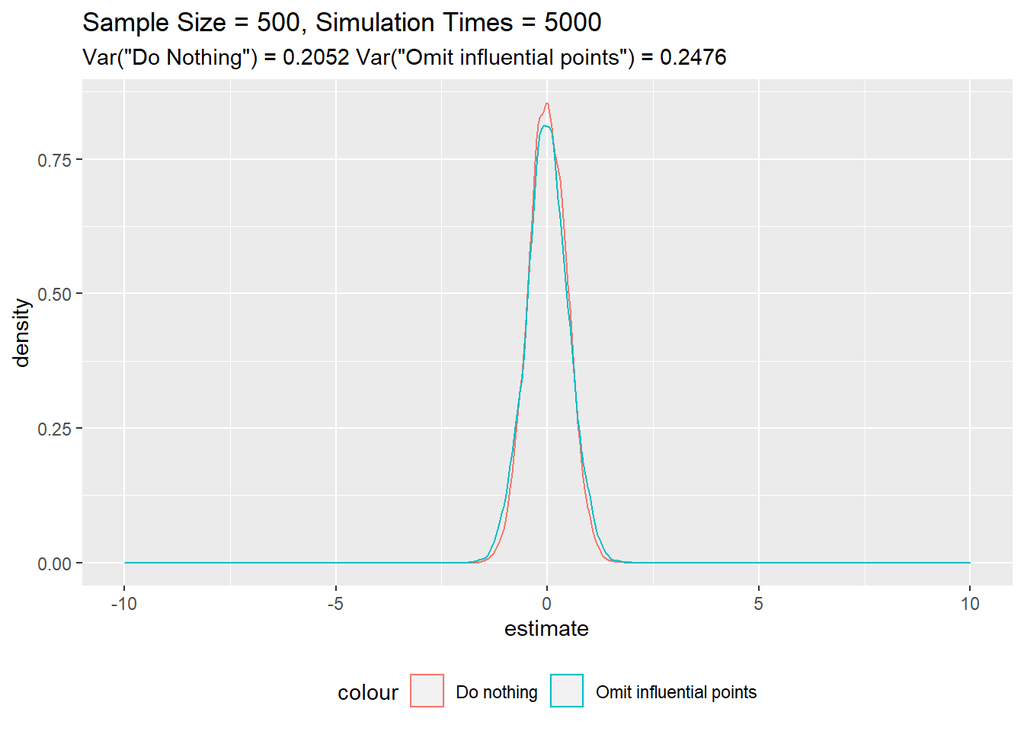

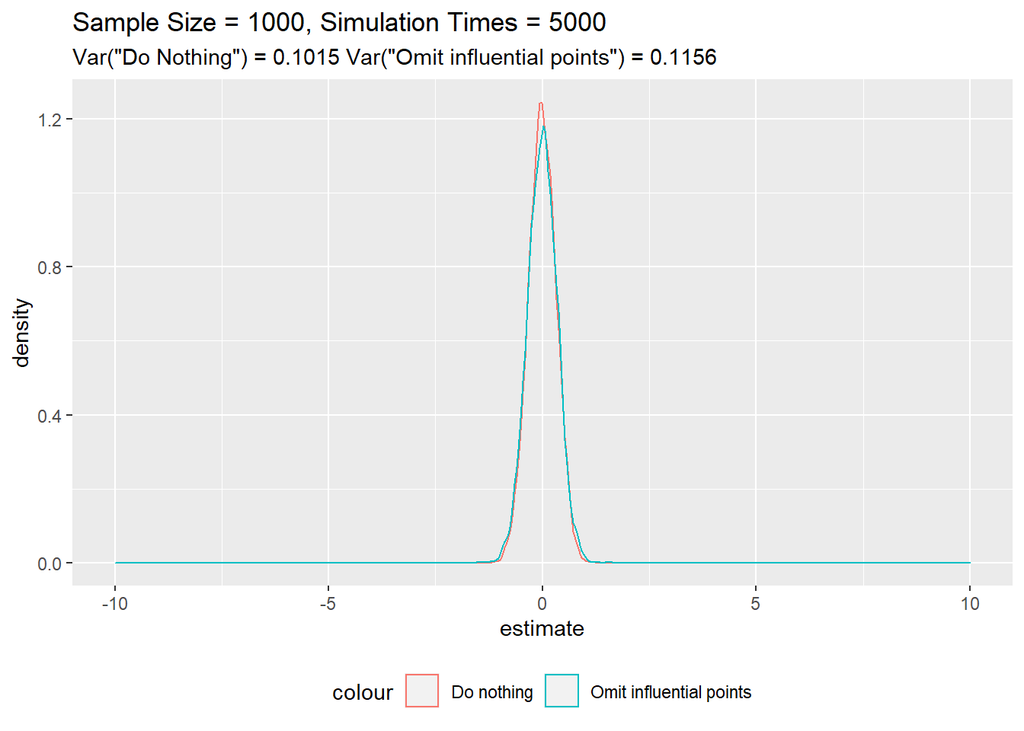

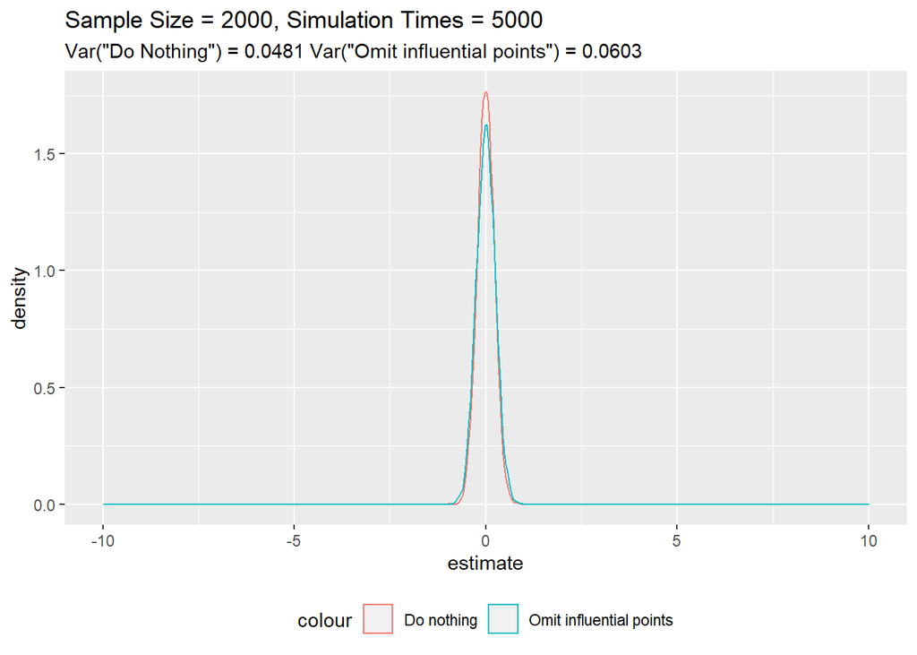

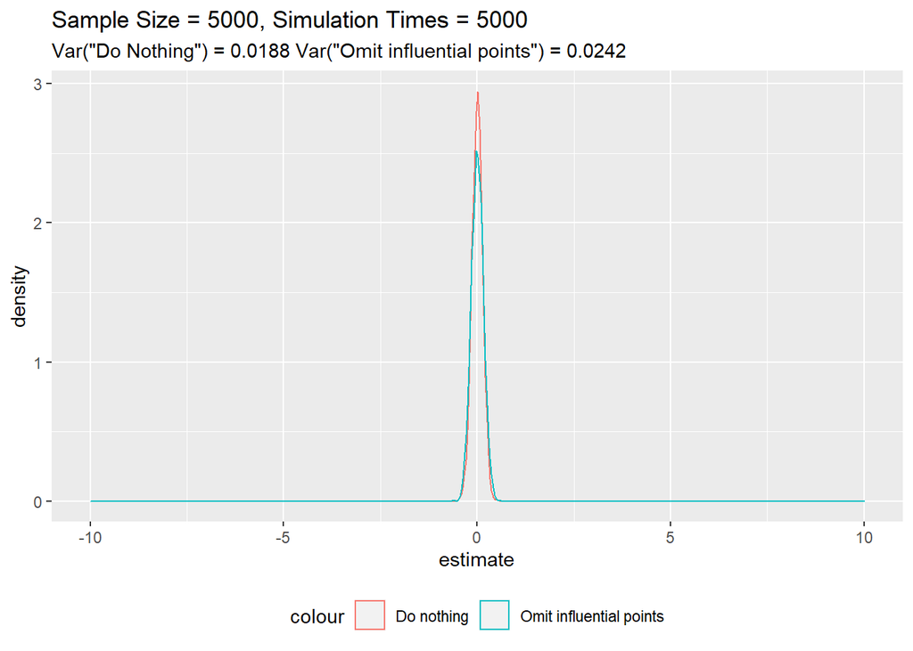

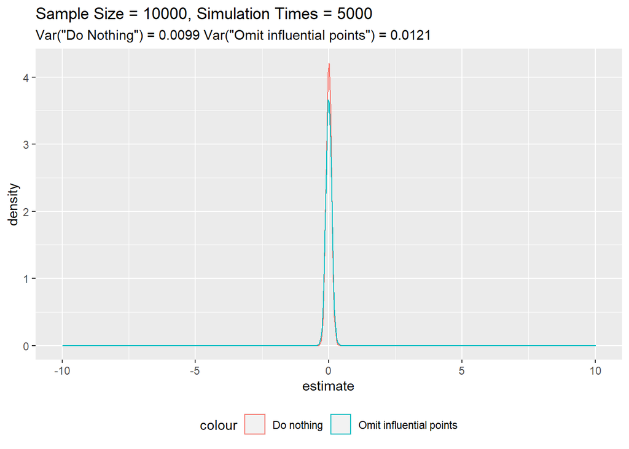

```r
mc <- function(T = 100, N = 100, cutoff = TRUE){

  estimate <- rep(NA, N)

  for (i in 1:N){

    y <- rnorm(T, sd = 10)
    mod <- lm(y~1)

    if (cutoff){
      y <- y[!cooks.distance(mod) > 4/T]
      mod <- lm(y~1)
    }

    estimate[i] <- as.numeric(mod$coefficients)
  }

  return(estimate)

}

set.seed(100)
N <- 5000

for (T in c(10, 20, 50, 100, 200, 500, 1000, 2000, 5000, 10000)){
  estimate_d <- mc(T = T, N = N, cutoff = TRUE)
  estimate <- mc(T = T, N = N, cutoff = FALSE)

  vard <- var(estimate_d)
  varn <- var(estimate)

  p <- ggplot() +
    geom_density(aes(estimate, col = "Do nothing")) +
    geom_density(aes(estimate_d, col = "Omit influential points")) +
    ggtitle(paste0("Sample Size = ", T, ", Simulation Times = ", N)) +
    xlim(c(-10, 10)) +
    theme(legend.position = "bottom") +
    labs(subtitle = paste0('Var("Do Nothing") = ',
                           round(varn, 4),
                           ' Var("Omit influential points") = ',
                           round(vard, 4)))

  print(p)
  #ggsave(paste0("plots/", T, ".jpeg"), plot = p)
}
```

# Heteroscedasticity

What if we encounter heteroscedasticity?

Assume we have such a dataset

95% of them have this DGP:

$$Y_t = \beta_0 + \varepsilon_t, \varepsilon_t \sim N(0,10^2), t = 1,2,..,T$$

And the remaining 5% have another DGP:

$$Y_t = \beta_0 + \varepsilon_t, \varepsilon_t \sim N(0,100^2), t = 1,2,..,T$$
You can consider this 5% of data to be outliers.

Using this dataset, we redo the experiment. This time, we can clearly see the benefit of dropping influential points. The sampling distribution of $\hat{\beta}_{0,Cook}$ is better.

In both methods, the estimator is consistent. You can prove it by using simple algebra.

**Therefore, when you feel there is a heteroscedasticity problem, you may try to drop influential points to boost your efficiency.**

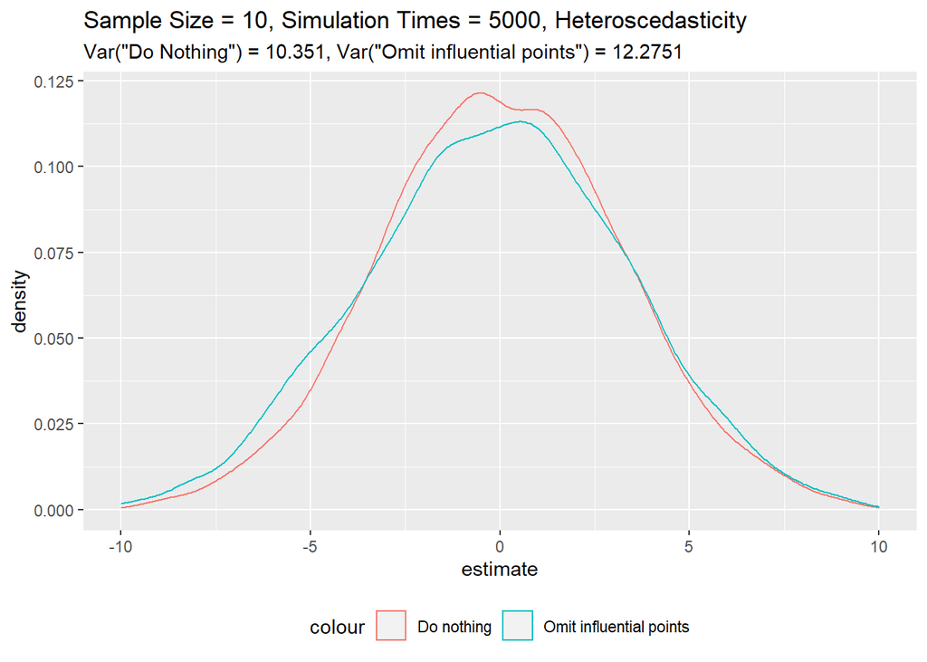

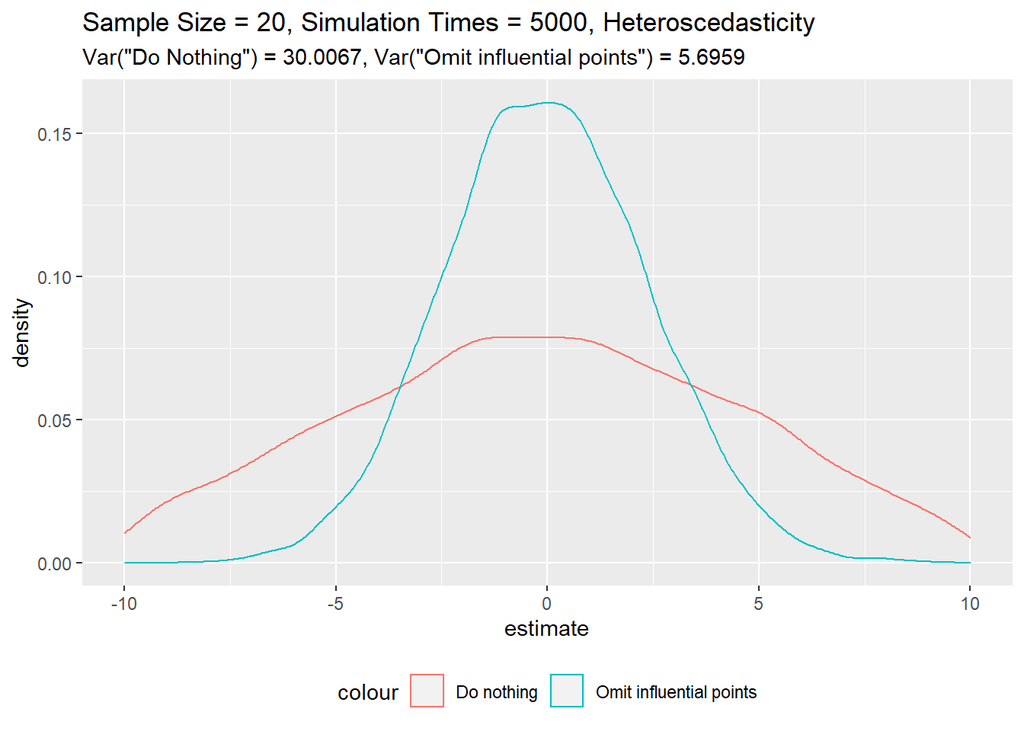

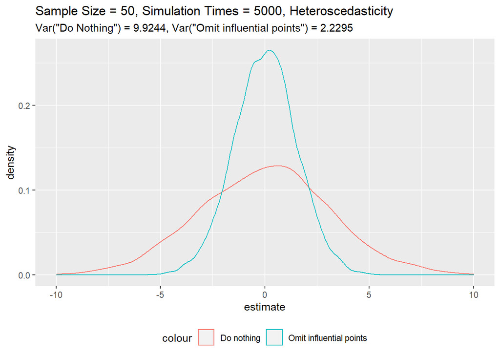

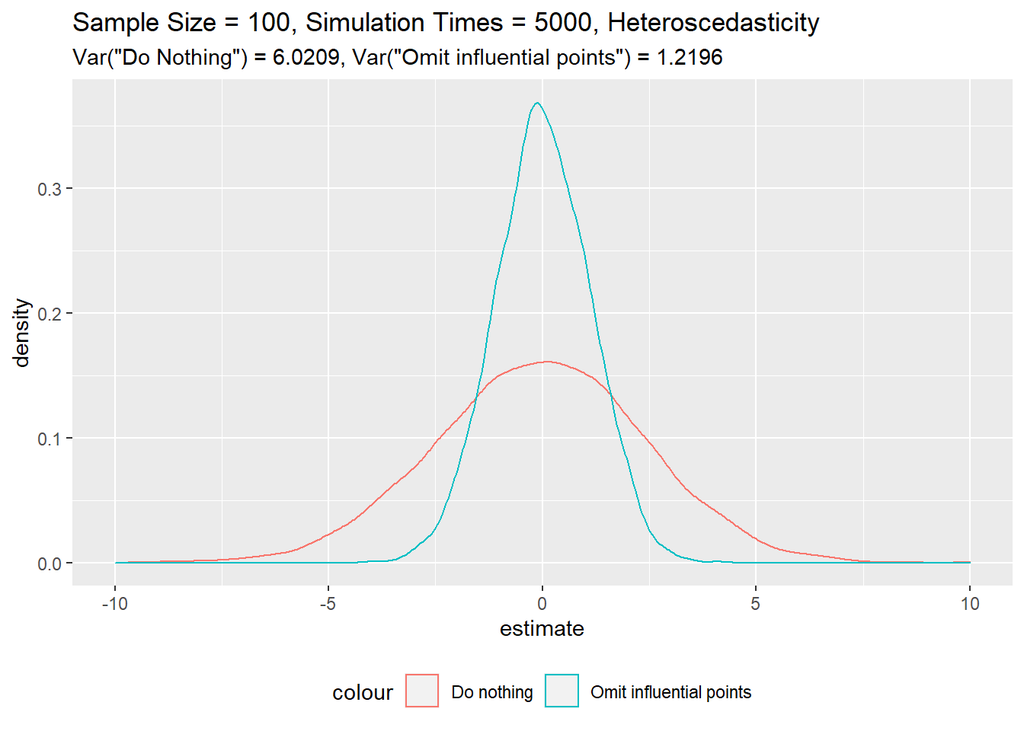

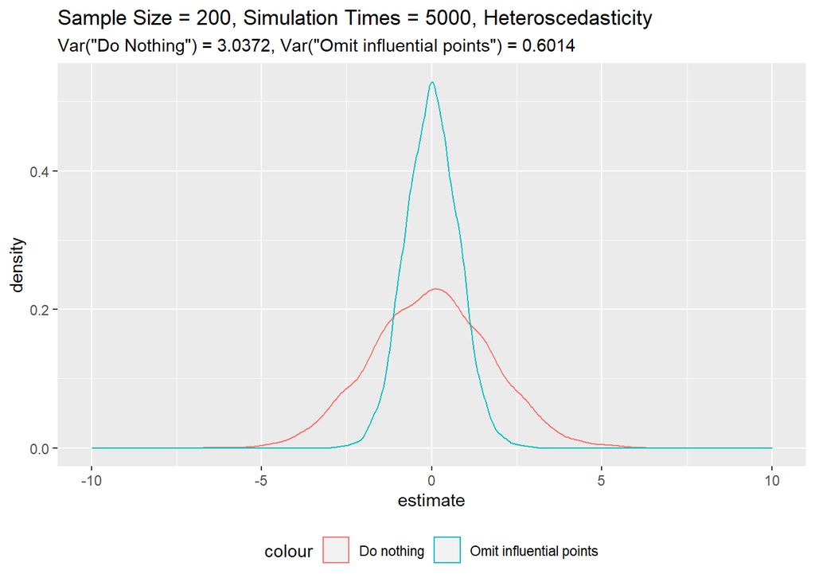

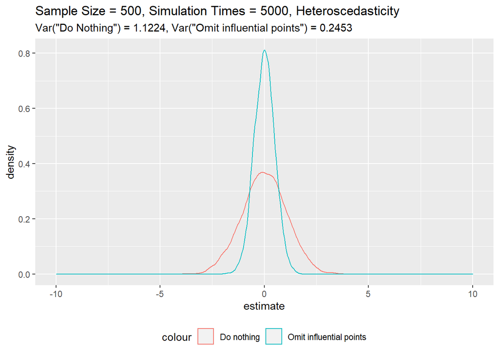

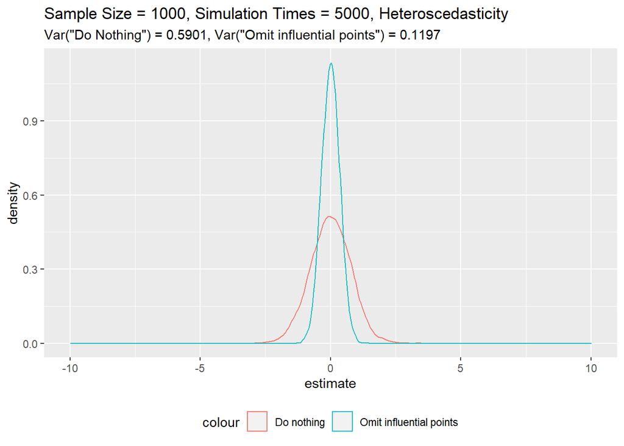

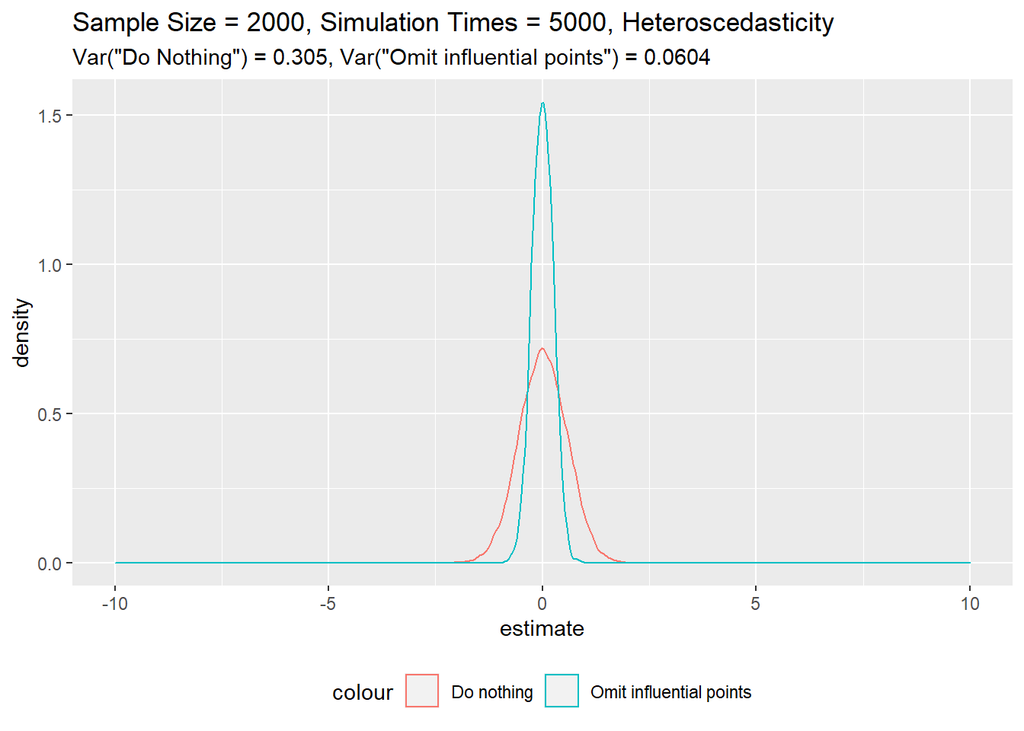

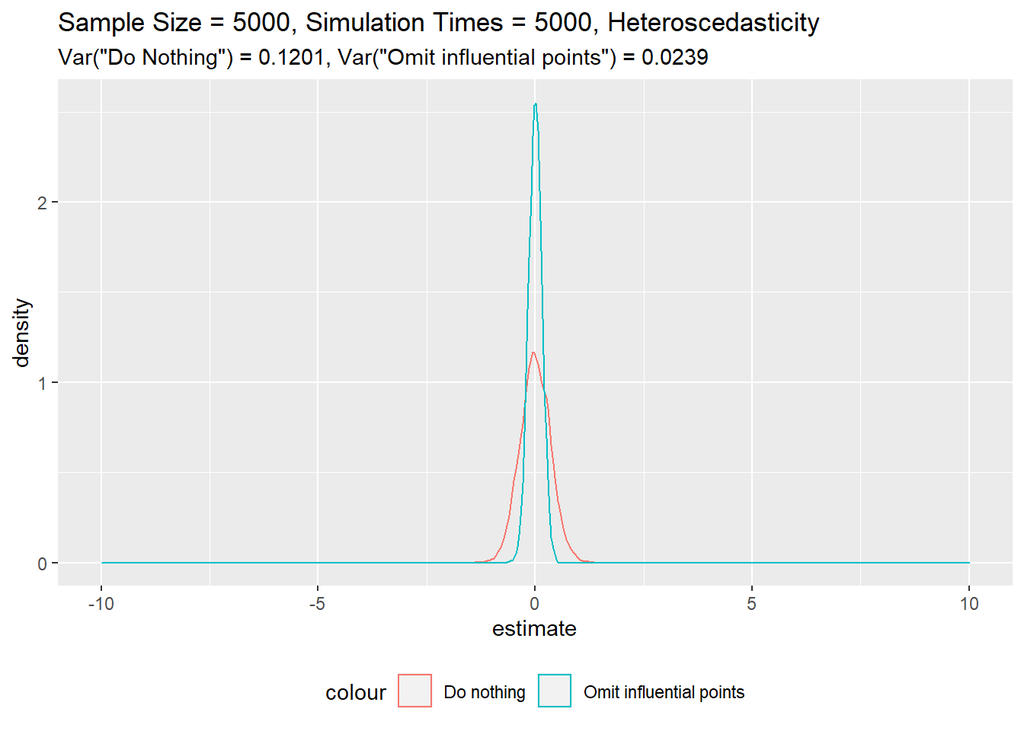

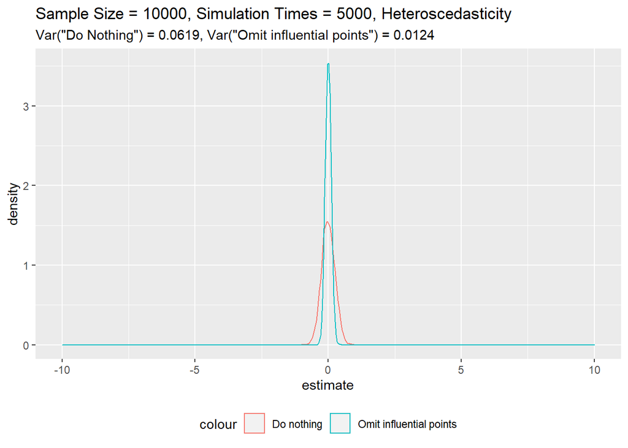

```r
mc2 <- function(T = 100, N = 100, cutoff = TRUE){

  estimate <- rep(NA, N)

  for (i in 1:N){

    y <- rnorm(round(T*0.95), sd = 10)
    y <- c(y, rnorm(T - round(T*0.95), sd = 100))
    mod <- lm(y~1)

    if (cutoff){
      y <- y[!cooks.distance(mod) > 4/T]
      mod <- lm(y~1)
    }

    estimate[i] <- as.numeric(mod$coefficients)
  }

  return(estimate)

}

set.seed(200)
N <- 5000

for (T in c(10, 20, 50, 100, 200, 500, 1000, 2000, 5000, 10000)){
  estimate_d <- mc2(T = T, N = N, cutoff = TRUE)
  estimate <- mc2(T = T, N = N, cutoff = FALSE)

  vard <- var(estimate_d)
  varn <- var(estimate)

  p <- ggplot() +
    geom_density(aes(estimate, col = "Do nothing")) +
    geom_density(aes(estimate_d, col = "Omit influential points")) +
    ggtitle(paste0("Sample Size = ", T, ", Simulation Times = ", N, ", Heteroscedasticity")) +
    xlim(c(-10, 10)) +
    theme(legend.position = "bottom") +
    labs(subtitle = paste0('Var("Do Nothing") = ',
                           round(varn, 4),
                           ', Var("Omit influential points") = ',
                           round(vard, 4)))

  print(p)
  #ggsave(paste0("plots/H-", T, ".jpeg"), plot = p)
}
```

# Two different DGPs

What if the mean is different?

Consider such a dataset consists of two groups of data,

the first group (95%) have such a DGP:

$$Y_t = \beta_0 + \varepsilon_t, \varepsilon_t \sim N(0,10^2), t = 1,2,..,T$$

the second group (5%) have such a DGP:

$$Y_t = \beta_0 + \varepsilon_t, \varepsilon_t \sim N(20,10^2), t = 1,2,..,T$$
We could immediately know that by using the `lm` function, we will get the $\hat{\beta}_0$ around $20 \times 5\% + 0 \times 95\% = 1$. But what if we just want to estimate the $\beta_0$ for the first group, which is 0?

Let’s see what will happen.

With no surprise, $\hat{\beta}_0$ will converge to 1. However, if we drop the influential points, we will end up getting the estimate $\hat{\beta}_{0,Cook}$ around 0.6, which is closer to 0.

**Therefore, if you believe there are a small proportion of noisy points that do not belong to your interesting group, try to drop influential points to reduce bias.**

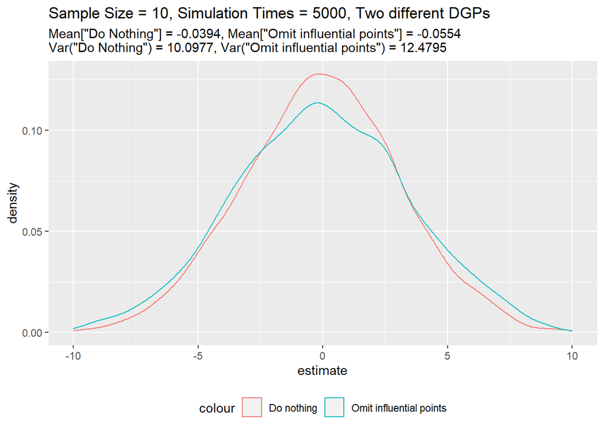

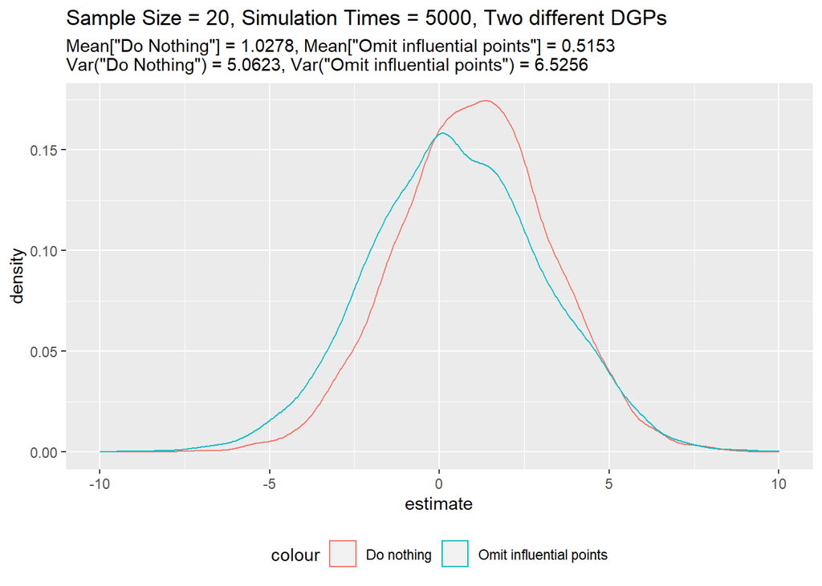

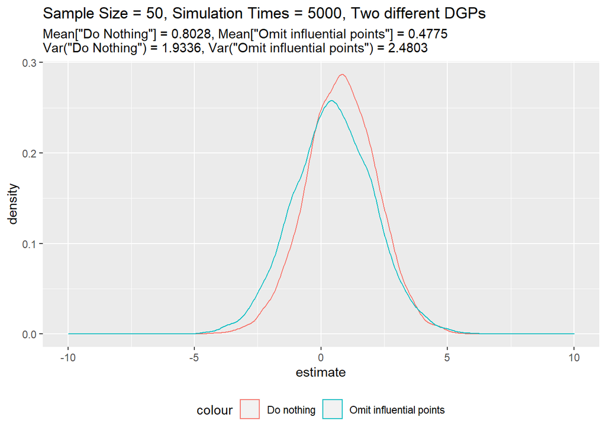

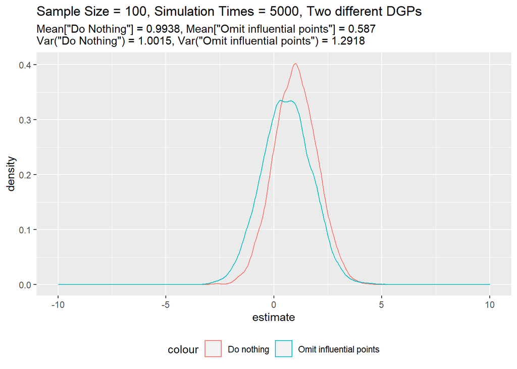

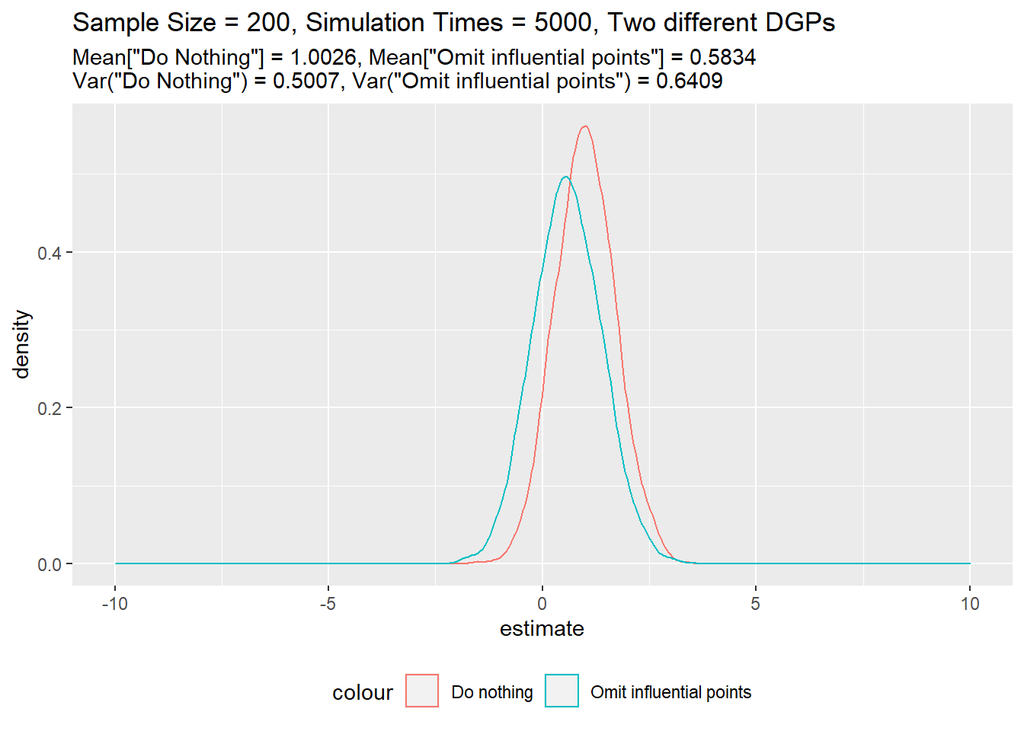

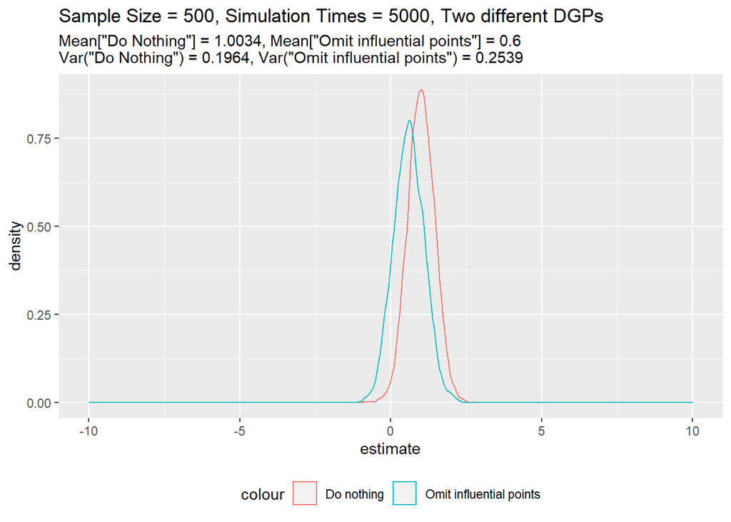

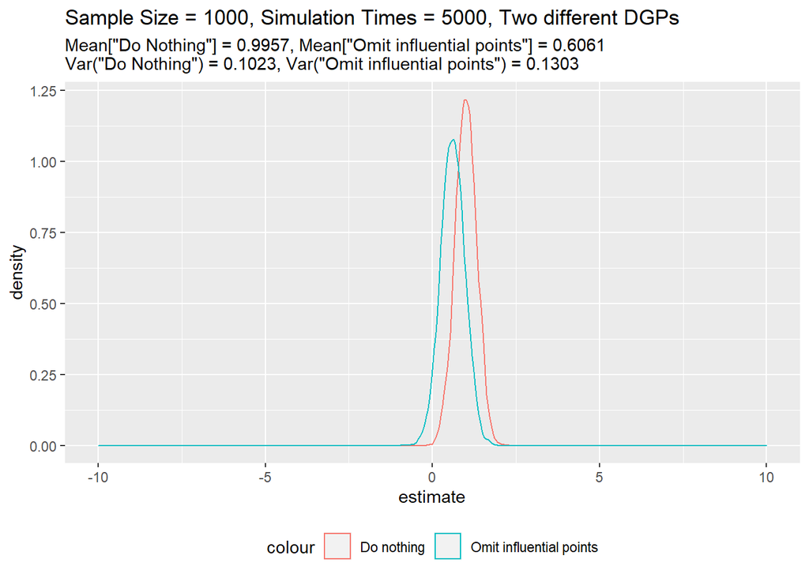

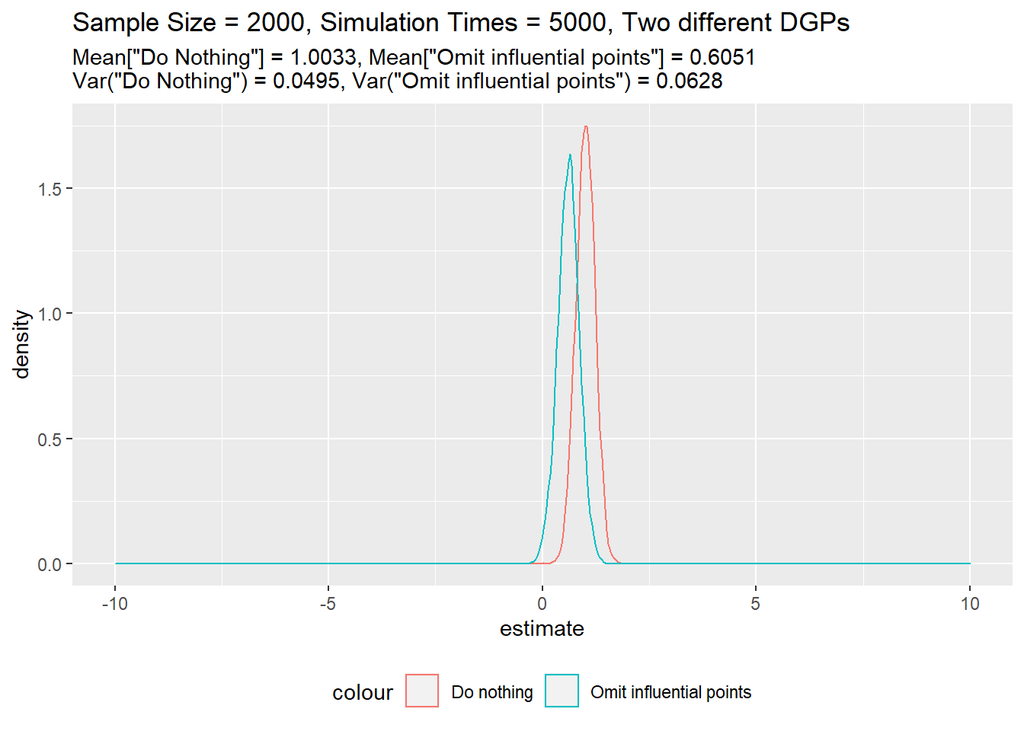

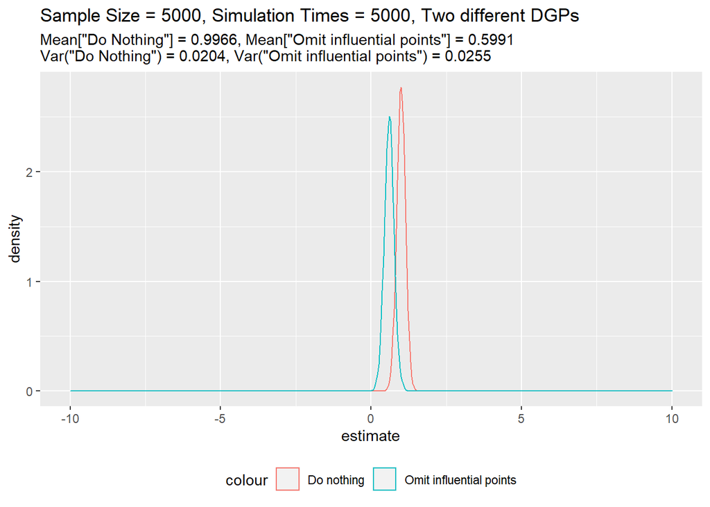

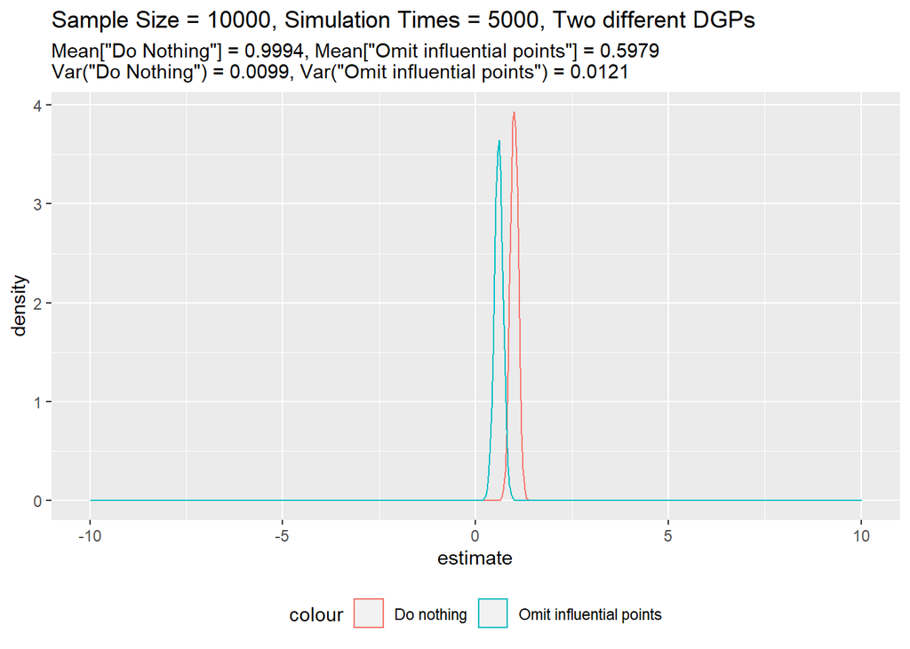

```r
mc3 <- function(T = 100, N = 100, cutoff = TRUE){

  estimate <- rep(NA, N)

  for (i in 1:N){

    y <- rnorm(round(T*0.95), sd = 10)
    y <- c(y, rnorm(T - round(T*0.95), mean = 20, sd = 10))
    mod <- lm(y~1)

    if (cutoff){
      y <- y[!cooks.distance(mod) > 4/T]
      mod <- lm(y~1)
    }

    estimate[i] <- as.numeric(mod$coefficients)
  }

  return(estimate)

}

set.seed(300)
N <- 5000

for (T in c(10, 20, 50, 100, 200, 500, 1000, 2000, 5000, 10000)){
  estimate_d <- mc3(T = T, N = N, cutoff = TRUE)
  estimate <- mc3(T = T, N = N, cutoff = FALSE)

  vard <- var(estimate_d)
  varn <- var(estimate)
  ed <- mean(estimate_d)
  en <- mean(estimate)

  p <- ggplot() +
    geom_density(aes(estimate, col = "Do nothing")) +
    geom_density(aes(estimate_d, col = "Omit influential points")) +
    ggtitle(paste0("Sample Size = ", T, ", Simulation Times = ", N, ", Two different DGPs")) +
    xlim(c(-10, 10)) +
    theme(legend.position = "bottom") +
    labs(subtitle = paste0('Mean["Do Nothing"] = ',
                           round(en, 4),
                           ', ',
                           'Mean["Omit influential points"] = ',
                           round(ed, 4),
                           '\n',
                           'Var("Do Nothing") = ',
                           round(varn, 4),
                           ', Var("Omit influential points") = ',
                           round(vard, 4)))

  print(p)
  #ggsave(paste0("plots/HM-", T, ".jpeg"), plot = p)
}
```